# Bayesian Ranking

21/11/2020

## Introduction

- Product Reviews are hard to interpret
- There is no easy way to know if you should choose between a 4,7 stars review with one hundreds reviews or one with five 5-star reviews
- And no one considers **you** - the expert - in the rankings

But now we have a solution: **The Bayesian Ranking Tool**

## Technology

- This Tool uses top of the line Bayesian algorithms to help you through your purchasing process
- Just type in all the votes &
- Choose how good the product is in **your** view * &
- How confident **you** are with your point of view * &
- How much risk **you** are willing to take
- Optional!

## Example

| Name | 5 Stars | 4 Stars | 3 Stars | 2 Stars | 1 Stars |
| --- | --- | --- | --- | --- | --- |
| Product 1 | 190 | 15 | 10 | 2 | 5 |
| Product 2 | 5 | 0 | 0 | 0 | 0 |

**You** consider Product 2 to be slightly better than Product 1. **You** are relatively confident. **You** want to be 90% sure!

## Result

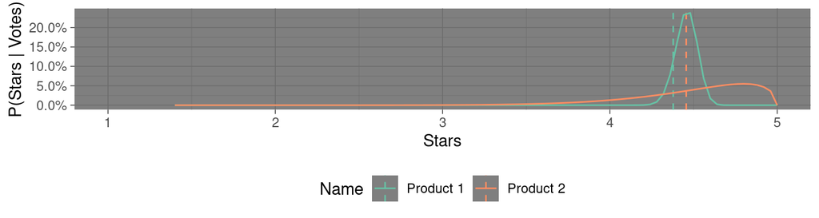

**You** should take Product 2! Bayesian magic at it’s best!

- The tool can help you with every purchase
- It is highly customizable and blends **your** expert knowledge and crowd knowledge seamlessly
- Try it yourself: [Link](https://pteridin.shinyapps.io/RBayesianRanking/)

Happy purchase!